# Will a data scientist leave your company?

**Introduction**

- The objective of this kernel is to predict whether a data scientist would leave the company or continue working there.
- I plan to use the HR_Analytics dataset to find an optimal set of parameters that would allow us to estimate the probability of an employee leave. This is a classification problem, thus I would apply various classification models for the assessment of the relationship between independent variables and the dependent variable (target) in this dataset.
- I have compared the most common classifiers and found that XGBoost classifier resulted in the highest recall score of 0.80 of those who plan to leave. I have opted for recall as a ultimate metrics because in this project we are trying to minimize the falls negative values, meaning: if we predicted that a person would not leave our company, but he or she actually did it, we would loose an average **60000$** as cost to hire a new specialist for this role. Thus, it is better if we predicted that a person would indeed leave the company, but he decided to stay (False positive), than other way around (False negative).

*** Please do UpVote this Notebook if you find it helpful!**

1. Quick glance at Data
2. My Hypothesis
3. Exploratory Data Analysis
4. A) Feature Engineering: Data Clustering
5. B) Feature Engineering: Missing values
6. Feature Selection
7. Model Building
8. Hyperparameter tuning
9. Model Evaluation
10. Deployment

```python
# import packages for analysis
import pandas as pd
import numpy as np
import seaborn as sns
import matplotlib.pyplot as plt
%matplotlib inline
plt.rcParams['figure.figsize'] = (12,8)
from sklearn.preprocessing import StandardScaler
from sklearn.preprocessing import LabelEncoder
from sklearn.linear_model import Lasso
from sklearn.linear_model import Ridge
from sklearn.ensemble import ExtraTreesRegressor
from sklearn.ensemble import GradientBoostingRegressor
from sklearn import metrics
from sklearn.naive_bayes import GaussianNB
from sklearn.neighbors import KNeighborsClassifier
from sklearn.svm import SVC
from sklearn.tree import DecisionTreeClassifier
from sklearn.ensemble import RandomForestClassifier
from sklearn.datasets import make_classification
from sklearn.metrics import confusion_matrix, classification_report, plot_roc_curve, roc_auc_score, roc_curve
from sklearn.linear_model import LogisticRegression
from sklearn.tree import DecisionTreeClassifier
from sklearn.ensemble import RandomForestClassifier, GradientBoostingClassifier
from xgboost import XGBClassifier
from sklearn.model_selection import RandomizedSearchCV
from sklearn.ensemble import GradientBoostingClassifier
from imblearn.over_sampling import SMOTE
import plotly.express as px
from matplotlib.pyplot import figure
from collections import defaultdict
import random
plt.style.use('ggplot')
pd.options.mode.chained_assignment = None
from collections import defaultdict
from imblearn.pipeline import Pipeline as imbPipe
from sklearn.model_selection import train_test_split
from sklearn.model_selection import cross_val_score
from sklearn.model_selection import GridSearchCV
from sklearn.metrics import classification_report
from sklearn.metrics import roc_auc_score,roc_curve
from imblearn.pipeline import Pipeline as imbPipe
from imblearn.over_sampling import SMOTE
from xgboost import  XGBClassifier
from sklearn.naive_bayes import GaussianNB
from sklearn.neighbors import KNeighborsClassifier
from sklearn.svm import SVC
from sklearn.tree import DecisionTreeClassifier
from sklearn.ensemble import RandomForestClassifier
import warnings
warnings.filterwarnings("ignore")
```

# Quick glance at Data

```python
#import libraries to read the file
import numpy as np # linear algebra
import pandas as pd # data processing, CSV file I/O (e.g. pd.read_csv)

import os
for dirname, _, filenames in os.walk('/kaggle/input'):
    for filename in filenames:
        print(os.path.join(dirname, filename))
```

```
/kaggle/input/hr-analytics-job-change-of-data-scientists/sample_submission.csv
/kaggle/input/hr-analytics-job-change-of-data-scientists/aug_test.csv
/kaggle/input/hr-analytics-job-change-of-data-scientists/aug_train.csv
```

```python
df_train = pd.read_csv('/kaggle/input/hr-analytics-job-change-of-data-scientists/aug_test.csv')
df_test = pd.read_csv('/kaggle/input/hr-analytics-job-change-of-data-scientists/aug_train.csv')

#I got used to work with complete datasets, thus I will just combine test and train datasets
df = df_train.append(df_test)
df.head()
```

|  | enrollee_id | city | city_development_index | gender | relevent_experience | enrolled_university | education_level | major_discipline | experience | company_size | company_type | last_new_job | training_hours | target |
| --- | --- | --- | --- | --- | --- | --- | --- | --- | --- | --- | --- | --- | --- | --- |
| 0 | 32403 | city_41 | 0.827 | Male | Has relevent experience | Full time course | Graduate | STEM | 9 | <10 | NaN | 1 | 21 | NaN |
| 1 | 9858 | city_103 | 0.920 | Female | Has relevent experience | no_enrollment | Graduate | STEM | 5 | NaN | Pvt Ltd | 1 | 98 | NaN |
| 2 | 31806 | city_21 | 0.624 | Male | No relevent experience | no_enrollment | High School | NaN | <1 | NaN | Pvt Ltd | never | 15 | NaN |
| 3 | 27385 | city_13 | 0.827 | Male | Has relevent experience | no_enrollment | Masters | STEM | 11 | 10/49 | Pvt Ltd | 1 | 39 | NaN |
| 4 | 27724 | city_103 | 0.920 | Male | Has relevent experience | no_enrollment | Graduate | STEM | >20 | 10000+ | Pvt Ltd | >4 | 72 | NaN |

```python
# shape and data types of the data
print(df.shape)
print(df.dtypes)
print()
print('Numeric columns:')
# select numeric columns
df_numeric = df.select_dtypes(include=[np.number])
numeric_cols = df_numeric.columns.values
print(numeric_cols)
print()
print('Non-numeric columns:')
# select non numeric columns
df_non_numeric = df.select_dtypes(exclude=[np.number])
non_numeric_cols = df_non_numeric.columns.values
print(non_numeric_cols)
```

```
(21287, 14)
enrollee_id                 int64
city                       object
city_development_index    float64
gender                     object
relevent_experience        object
enrolled_university        object
education_level            object
major_discipline           object
experience                 object
company_size               object
company_type               object
last_new_job               object
training_hours              int64
target                    float64
dtype: object

Numeric columns:
['enrollee_id' 'city_development_index' 'training_hours' 'target']

Non-numeric columns:
['city' 'gender' 'relevent_experience' 'enrolled_university'
 'education_level' 'major_discipline' 'experience' 'company_size'
 'company_type' 'last_new_job']
```

Quick summary: Most features are categorical (Nominal, Ordinal)

Features:

- enrollee_id : Unique ID of employee
- city: City code
- city_development_index: Developement index of the city (scaled)
- gender: Gender of employee
- relevent_experience: Relevent experience of employee
- enrolled_university: Type of University courses employee if any
- education_level: Education level of employee
- major_discipline :Education major discipline of employee
- experience: employee total experience in years
- company_size: No of employees in current employer's company
- company_type : Type of current employer
- lastnewjob: Difference in years between previous job and current job
- training_hours: training hours completed
- target: 0 – Not looking for job change, 1 – Looking for a job change

# My Hypothesis

**My initial hypothesis was that relevant_experience, training_hours and experience would influence the candidate's decision to leave the company at most**

# Exploratory Data Analysis

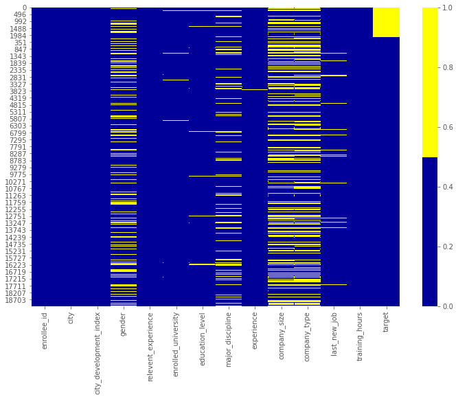

```python
#working with missing values
cols = df.columns
colours = ['#000099', '#ffff00'] # specify the colours - yellow is missing. blue is not missing.
sns.heatmap(df[cols].isnull(), cmap=sns.color_palette(colours))
```

Regarding missing values, we we will perform exploratory data analysis, and then we will estimate the feature importance of each independent variable in respect to the target feature, so we will not have to impute nan values for all variables, just for those that significantly correlated with the target.

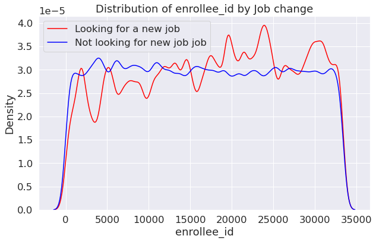

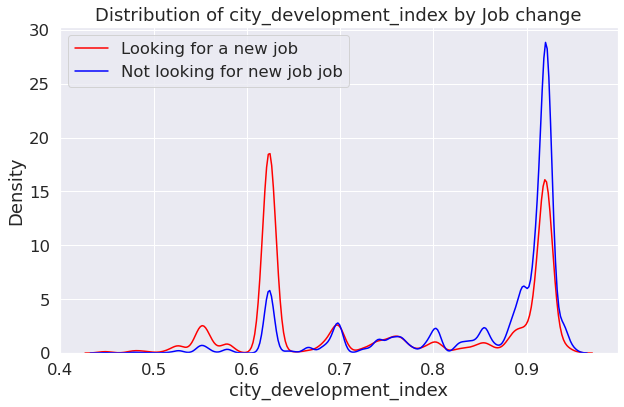

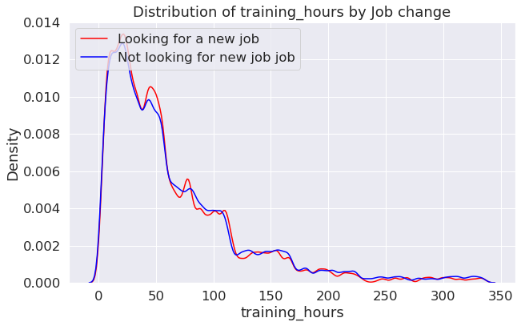

```python
# lets see the density distribution of the numerical columns corresponding target features
df_numeric.columns

for i in df_numeric.columns[:-1]:
    sns.set(font_scale=1.5)
    plt.figure(figsize=[10,6])
    ax = sns.kdeplot(df_numeric[i][(df_numeric["target"] == 1) ],color="red", bw = .05, shade=False, gridsize=300)
    ax = sns.kdeplot(df_numeric[i][(df_numeric["target"] == 0) ],color="blue", bw=.05, shade=False, gridsize=300)
    ax.legend(["Looking for a new job","Not looking for new job job"],loc='upper left')
    ax.set_ylabel('Density')
    ax.set_xlabel(i)
    ax.set_title("Distribution of "+ i +" by Job change");
```

According to the EDA analysis of numeric columns, enrolee_id has no effect on the target feature, however city_development index did influence the target: job candidates living in cities with lower development index **look for a new job 3 times more frequently** than those who prefer to stay in the company. Regarding the cities with high development index, the number of employees planning to leave the job is **around 2 times lower** than those who intended to stay. I could not observe a clear dependence of those who got trained less or more on their tendency to leave or stay in the company.

```python
df.columns
```

```
Index(['enrollee_id', 'city', 'city_development_index', 'gender',
       'relevent_experience', 'enrolled_university', 'education_level',
       'major_discipline', 'experience', 'company_size', 'company_type',
       'last_new_job', 'training_hours', 'target'],
      dtype='object')
```

```python
#droping less important columns
df1 = df.copy()
df1.drop(columns = ['enrollee_id', 'training_hours'], inplace = True)
```

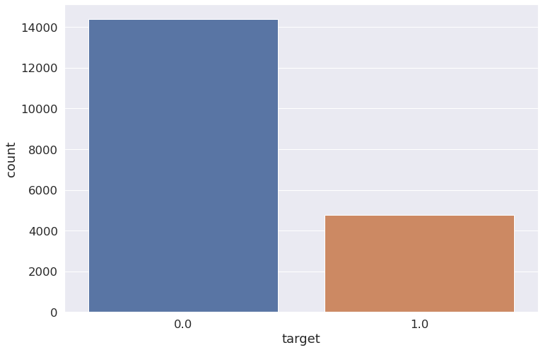

```python
# Lets take a look at the target feature
sns.set(font_scale=1.5)
sns.countplot(data=df, x='target')
plt.show()
```

The target variable is clearly imbalanced , we can deal with it later, in the data preprocessing section. We observe that most of the data scientist 3 times more decided to stay in company. We should not be surprised when this proportion (0/1) will appear during the EDA of categorical features.

```python
#Lets check how categorical features influence the target variable
df_non_numeric.columns[:-1]
```

```
Index(['city', 'gender', 'relevent_experience', 'enrolled_university',
       'education_level', 'major_discipline', 'experience', 'company_size',
       'company_type'],
      dtype='object')
```

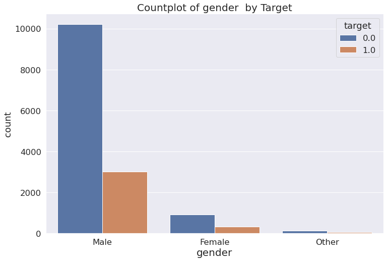

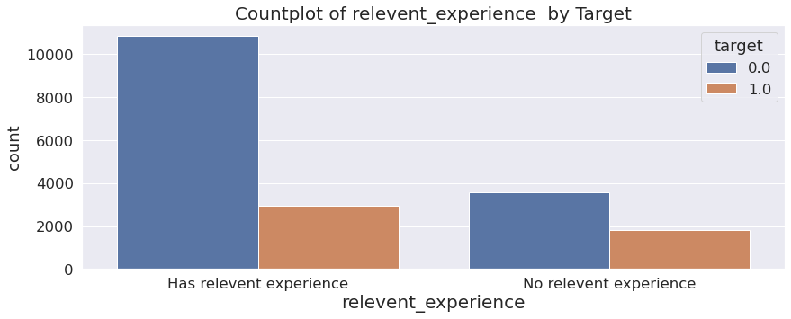

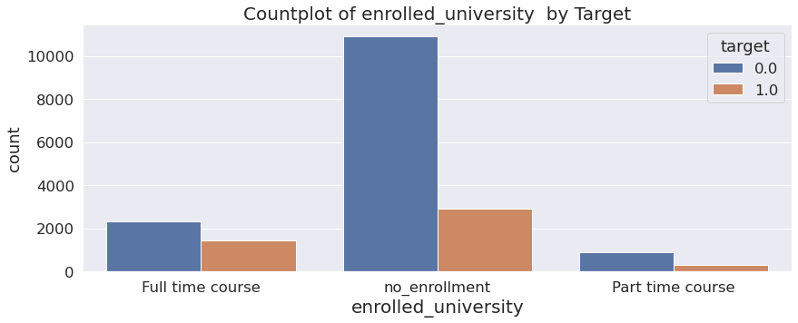

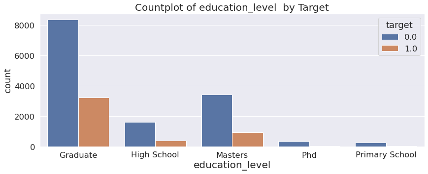

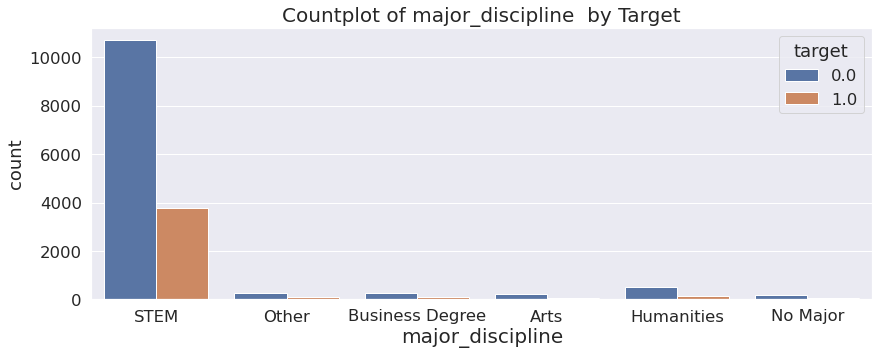

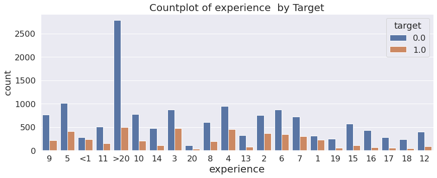

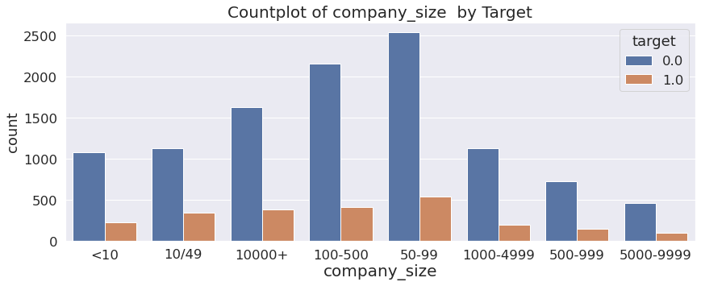

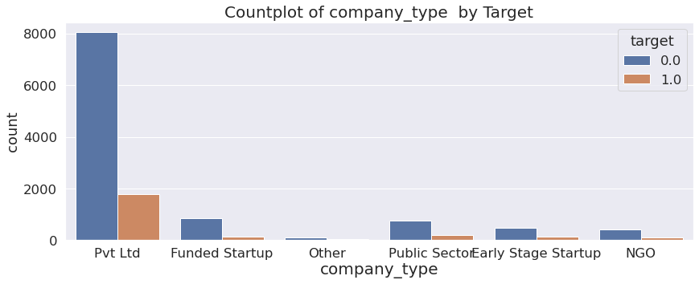

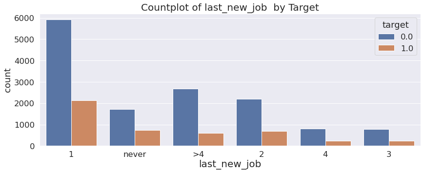

```python
for i, col in enumerate(df_non_numeric.columns[1:]):
    sns.set(font_scale=1.5)
    plt.figure(i)
    plt.title("Countplot of {}  by Target".format(col),fontsize=20)
    g= sns.countplot(x=col, hue = 'target', data=df)
    g.set_xlabel(col, fontsize = 20)
    plt.figure(figsize=[14,5])
```

**If there is no ifluence of the independent variable onto the target feature, we are supposed to get the ratio of 3 to 1 for 0 and 1 (target feature) according to the countplot above of target feature. If the ratio of 0 and 1 is different from 3 to 1 (3/1), that means that there is an effect (positive or negative) on the independent variable onto the target feature.**

**My updated hypostesis: It looks like that I was wrong saying that relevant_experience, training_hours and experience would play a major role in determining teh terget feature. In contrast, according to the EDA analysis it looks like that only city_development index would considerably influence the employee decision whether to stay or to leave the company.**

```python
df1.columns
```

```
Index(['city', 'city_development_index', 'gender', 'relevent_experience',
       'enrolled_university', 'education_level', 'major_discipline',
       'experience', 'company_size', 'company_type', 'last_new_job', 'target'],
      dtype='object')
```

```python
# droping less important columns
# city columns itself could serve as index, but I prefer to just drop it
df1.drop(columns = ['city', 'gender', 'major_discipline', 'company_type'], inplace = True)
```

# Feature Engineering: Data Clustering

In this section we will do some Data Preprocessing for company_size and experience to reduce the number of values in those columns by clustering them

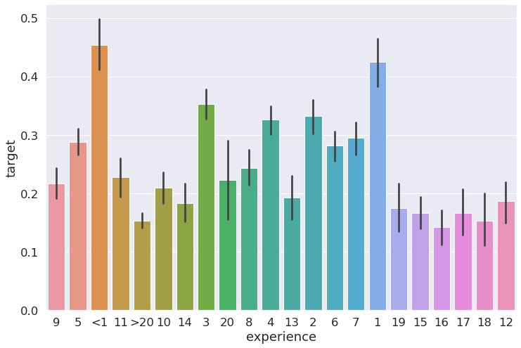

```python
#starting with experience column
#this is what we have right after EDA analysis
sns.set(font_scale=1.5)
sns.barplot(x=df['experience'], y = 'target', data=df)
```

kind of difficult to grasp what is going on here, thus lets transform the data into 4 clusters

```python
df1.head()
```

|  | city_development_index | relevent_experience | enrolled_university | education_level | experience | company_size | last_new_job | target |
| --- | --- | --- | --- | --- | --- | --- | --- | --- |
| 0 | 0.827 | Has relevent experience | Full time course | Graduate | 9 | <10 | 1 | NaN |
| 1 | 0.920 | Has relevent experience | no_enrollment | Graduate | 5 | NaN | 1 | NaN |
| 2 | 0.624 | No relevent experience | no_enrollment | High School | <1 | NaN | never | NaN |
| 3 | 0.827 | Has relevent experience | no_enrollment | Masters | 11 | 10/49 | 1 | NaN |
| 4 | 0.920 | Has relevent experience | no_enrollment | Graduate | >20 | 10000+ | >4 | NaN |

```python
#some data cleaning and preprocessing
df1['experience'] = df1['experience'].replace('<1', '1').replace('>20', '20')

#necessary float conversion for cut function
df1['experience'] = df1['experience'].astype(float)

#Looking at the number of years in experience column I have decided to separate them into 4 groups:
#junior, middle, senior, and expert
df1['experience'] = pd.cut(df1['experience'], bins=4,
                      labels=['junior', 'middle', 'senior', 'expert'])
```

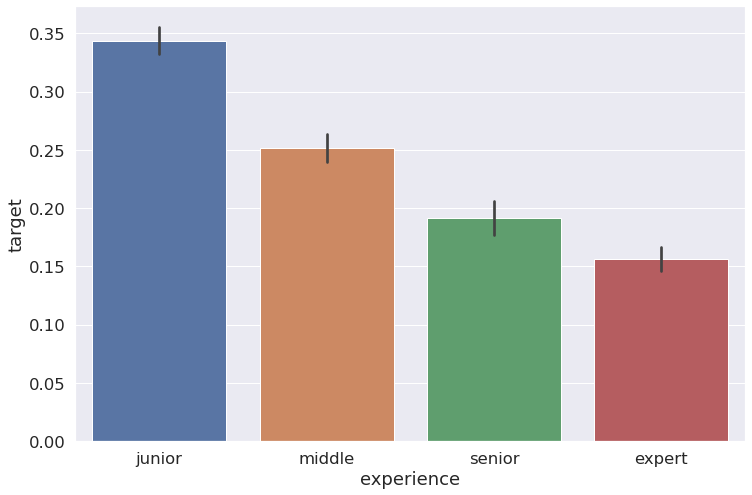

```python
#Lets see what we got
sns.set(font_scale=1.5)
sns.barplot(x=df1['experience'], y = 'target', data=df1)
```

Looking good!

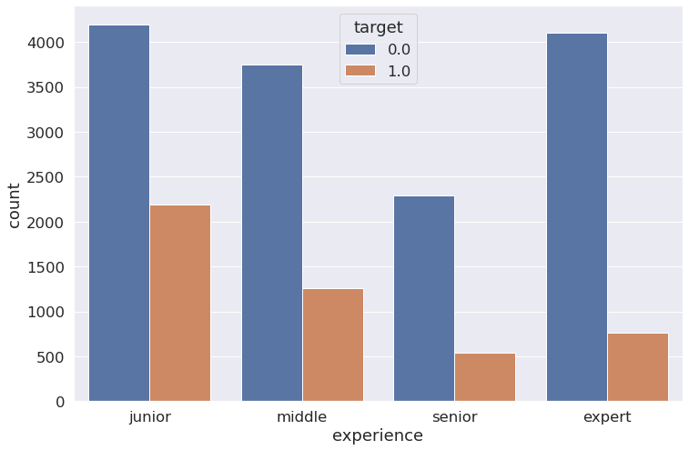

```python
#Lets see what we got
sns.set(font_scale=1.5)
sns.countplot(x=df1['experience'], hue = 'target', data=df1)
```

We remember that the initial distribution of 0 and 1 for the target feature is 3/1, so, for junior this ratio is about 2/1 (more ones than zeroes than for initial distribution of the target feature), meaning that Junior most likely would leave the job whereas expert prefer to stay in the company 4.5/1.

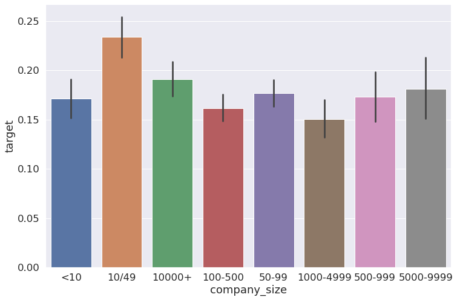

```python
#lets work with the compaby_size data
#this is what we right after EDA analysis
sns.set(font_scale=1.5)
sns.barplot(x=df['company_size'], y = 'target', data=df)
```

```python
#some data preprocessing
df1['company_size'] = df1['company_size'].replace('<10', '10').replace('10/49', '10-49')

#necessary float conversion for cur function
#temporarily substiturte the null values as 0, then we group this group as unknown
df1['company_size'] = df1['company_size'].fillna(0).astype(str)

#need to assign categories for each "categorical cluster" prior to imputation
categories = np.array(['small', 'middle', 'large', 'unknown'])
categories
```

```
array(['small', 'middle', 'large', 'unknown'], dtype='<U7')
```

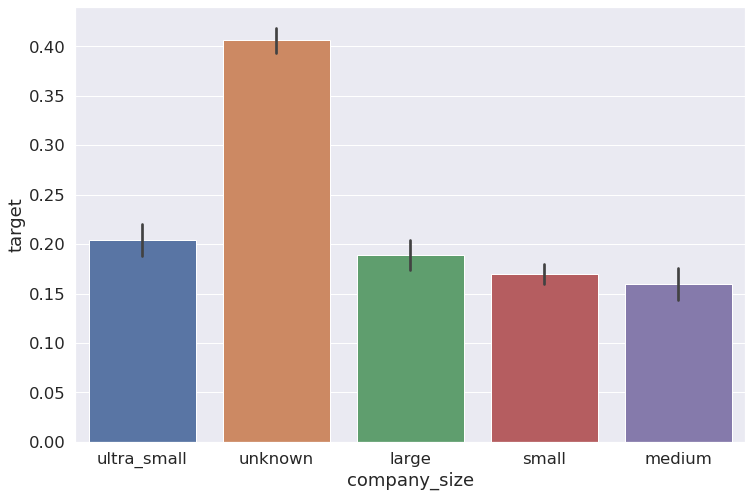

```python
# company_size data clustering into 5 categories
df1.loc[(df1['company_size'] == '10') | (df1['company_size'] == '10-49'),'company_size'] = 'ultra_small'
df1.loc[(df1['company_size'] == '50-99') | (df1['company_size'] == '100-500'),'company_size'] = 'small'
df1.loc[(df1['company_size'] == '500-999') | (df1['company_size'] == '1000-4999'),'company_size'] = 'medium'
df1.loc[(df1['company_size'] == '5000-9999') | (df1['company_size'] == '10000+'),'company_size'] = 'large'
df1.loc[(df1['company_size'] == '0'), 'company_size'] = 'unknown'
sns.set(font_scale=1.5)
sns.barplot(x=df1['company_size'], y = 'target', data=df1)
```

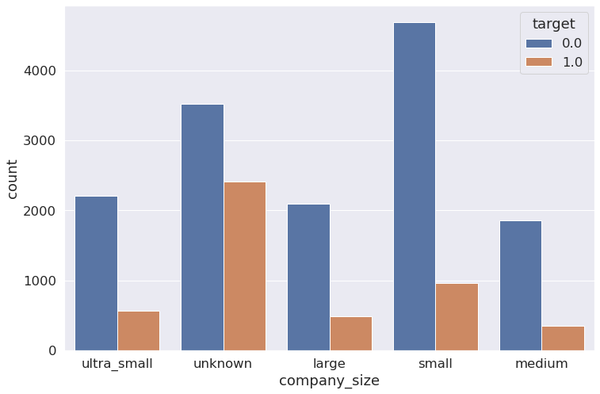

```python
#Lets see what we got
sns.set(font_scale=1.5)
sns.countplot(x=df1['company_size'], hue = 'target', data=df1)
```

We remember that the initial distribution of 0 and 1 for the target feature is 3/1, so, for small and medium sized companies the ratio of 0 and 1 is about 5/1 meaning that employees tend to stay in those companies. For ultra small and large companies the distribution of 0 and 1 is about the 3/1, which is similar to the initial ration of 0 and 1 if target feature. There are many unknown values, which we need to take into account later.

After Feature Engineering we can narrow our search down to the following variables:

1. city_development_index
2. experience
3. enrolled_university
4. education_level
5. relevant_experience
6. last_new_job

# Feature Engineering: Missing values

```python
#Lets see what missing values we need to impute
missing = pd.DataFrame(df1.isnull().sum()/len(df1), columns=['Missing'])

cm = sns.light_palette("red", as_cmap=True)
missing.style.background_gradient(cmap=cm)
```

|  | Missing |
| --- | --- |
| city_development_index | 0.000000 |
| relevent_experience | 0.000000 |
| enrolled_university | 0.019589 |
| education_level | 0.024052 |
| experience | 0.003288 |
| company_size | 0.000000 |
| last_new_job | 0.021750 |
| target | 0.100014 |

```python
df1.head()
```

|  | city_development_index | relevent_experience | enrolled_university | education_level | experience | company_size | last_new_job | target |
| --- | --- | --- | --- | --- | --- | --- | --- | --- |
| 0 | 0.827 | Has relevent experience | Full time course | Graduate | middle | ultra_small | 1 | NaN |
| 1 | 0.920 | Has relevent experience | no_enrollment | Graduate | junior | unknown | 1 | NaN |
| 2 | 0.624 | No relevent experience | no_enrollment | High School | junior | unknown | never | NaN |
| 3 | 0.827 | Has relevent experience | no_enrollment | Masters | senior | ultra_small | 1 | NaN |
| 4 | 0.920 | Has relevent experience | no_enrollment | Graduate | expert | large | >4 | NaN |

**Handling categorical features_adding a variable to capture NAN**

I do not want to delete the nan values neither to impute them with 0 or median. I plan to find another feature from the dataset that has some meaningful correlarion with feature with nan values

```python
#Encoding the last_new_job variable
df1['last_new_job'] = df1['last_new_job'].replace('>4', 5).replace('never', 0)
```

```python
#Encoding the experience variable
exp = {'Has relevent experience': 0, 'No relevent experience': 1}
df1['relevent_experience'] = df1['relevent_experience'].map(exp)
```

```python
df.columns
```

```
Index(['enrollee_id', 'city', 'city_development_index', 'gender',
       'relevent_experience', 'enrolled_university', 'education_level',
       'major_discipline', 'experience', 'company_size', 'company_type',
       'last_new_job', 'training_hours', 'target'],
      dtype='object')
```

**If we would observe the dependence of one independent feature on another one, we can tr to impute the m issing values based on this correlation, which is better that imputing nan's with 0 or median**

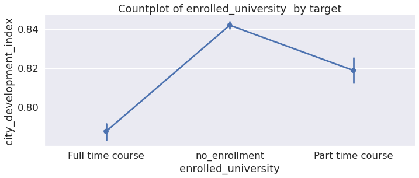

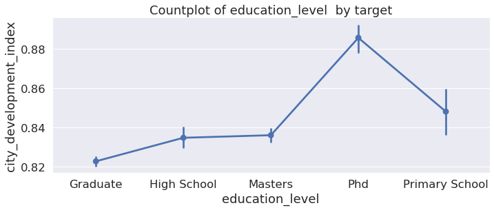

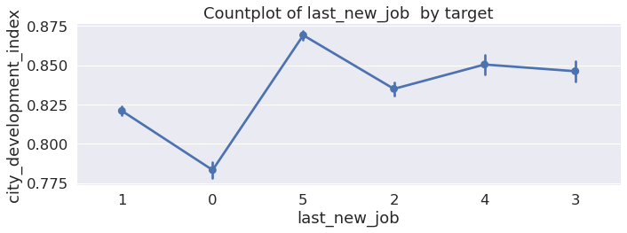

```python
sns.set(font_scale=1.5)
columns_to_plot = ['enrolled_university', 'education_level', 'last_new_job']

plt.figure(figsize=[20,6])
for column in columns_to_plot:

    ax = sns.factorplot(column, 'city_development_index', data=df1, size=4, aspect=2.5)
    plt.title("Countplot of {}  by target".format(column))

plt.tight_layout()
plt.show()
```

```python
#encoding enrolled_university missing values with correlated feature: city_development_index
df1.loc[(df1.enrolled_university.isnull()) &
(df1.city_development_index >= 0.83),'enrolled_university']= 'no_enrollment'

df1.loc[(df1.enrolled_university.isnull()) &
(df1.city_development_index <= 0.79),'enrolled_university']= 'Full time course'

df1.loc[(df1.enrolled_university.isnull()) &
((df1.city_development_index > 0.79)
 & (df1.city_development_index < 0.83)),'enrolled_university']= 'Part time course'
```

```python
#encoding education_level missing values with correlated feature: city_development_index
df1.loc[(df1.education_level.isnull()) &
(df1.city_development_index > 0.85),'education_level']= 'PhD'

df1.loc[(df1.education_level.isnull()) &
(df1.city_development_index < 0.83),'education_level']= 'Graduate'

df1.loc[(df1.education_level.isnull()) &
(df1.city_development_index >= 0.83) &
(df1.city_development_index <= 0.84),'education_level']= 'High School'


df1.loc[(df1.education_level.isnull()) &
(df1.city_development_index >= 0.845) &
(df1.city_development_index <= 0.85),'education_level']= 'High School'
```

```python
#encoding last_new_job missing values with correlated feature: city_development_index
df1.loc[(df1.last_new_job.isnull()) &
        (df1.city_development_index <= 0.83) & (df1.city_development_index >= 0.80),'last_new_job']= 1


df1.loc[(df1.last_new_job.isnull()) & (df1.city_development_index > 0.83)
        & (df1.city_development_index <= 0.84),'last_new_job']= 2


df1.loc[(df1.last_new_job.isnull()) & (df1.city_development_index > 0.84)
        & (df1.city_development_index <= 0.86),'last_new_job']= 4


df1.loc[(df1.last_new_job.isnull()) & (df1.city_development_index > 0.86),'last_new_job']= 5

df1.loc[(df1.last_new_job.isnull()) & (df1.city_development_index < 0.80),'last_new_job']= 0

df1['last_new_job'] = df1['last_new_job'].astype(int)
```

```python
missing = pd.DataFrame(df1.isnull().sum()/len(df1), columns=['Missing'])

cm = sns.light_palette("red", as_cmap=True)
missing.style.background_gradient(cmap=cm)
```

|  | Missing |
| --- | --- |
| city_development_index | 0.000000 |
| relevent_experience | 0.000000 |
| enrolled_university | 0.000000 |
| education_level | 0.000047 |
| experience | 0.003288 |
| company_size | 0.000000 |
| last_new_job | 0.000000 |
| target | 0.100014 |

How to impute the target variable?

So far we have found three columns with clear effect on the target variable: it depends on the expereince, the company_size and enrolled_university.

**Which one to choose?**